# Computer Science project.

Maksims Kovalovs

# Analysis

## Introduction

Even though the video game industry didn’t exist 4 decades ago, it is now one of the most popular hobbies of youth nowadays. With new variations on the original idea like mobile games and virtual reality games, it is likely that these games are here to stay for a long time. This project is about making a 8 ball pool game with a top down view that can be played by 2 players on the same computer.

## Identification of End Users

The main end users of this project are my school friends who are interested in playing a computer version of pool. The code will include the physical formulas of collisions and friction, and because this project will open-source and available online, this game might help other people to understand how 2-dimensional ball physics work.

## Available Alternatives

Most pool games online are hosted on online game websites like www.miniclip.com. At the time of writing this, the 8 ball pool game is the top game on the website and google says that the game was reviewed 1,563,388 times (Figure 1). This shows that there is a market for these types of games. Online websites don’t provide the source code for their games which means that the users cannot learn about how the physics of the game work, but also the users won’t be able to customize the game options like ball size or color.

[figure not shown]

The first result of Google search of “pool game”

I’ve looked on GitHub for pool games and there were some projects like mine, but most of the projects we’re abandoned, or unfinished [4]. For example, the user raysmith619 has a similar repository. In his README file he says that the game is missing the pockets, friction and ball rotation animations. I see these things as very important to the game and will implement them.

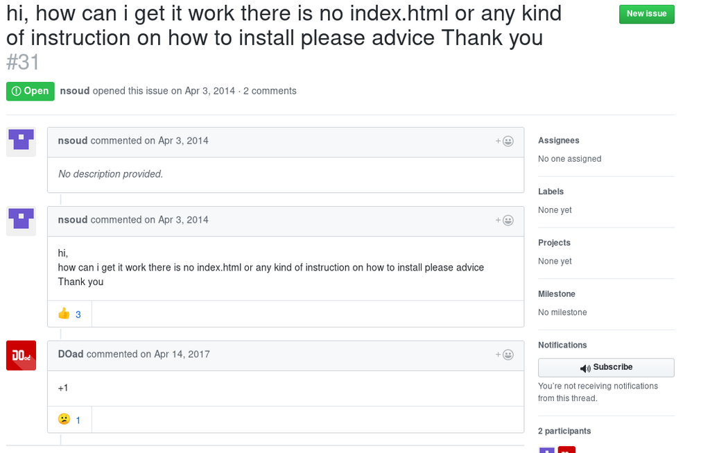

People having problems installing the pool game (GitHub issue)

Additionally, looking at commit messages (Figure 2), you can see that the main maintainer was trying to add advertisements to the game, which is a bad idea for this project, because ads will make the user experience worse[9].

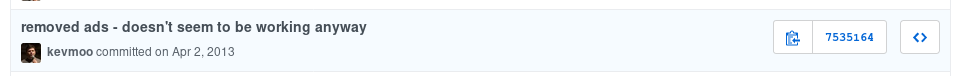

GitHub commit message

To summarise, my game should have parts the mentioned games didn’t have - pockets, friction and ball rotation animations. The game should have an instruction of how to install the game, so that users could acquire the game easily. Also, there should be a configuration file, so that some properties of the game objects, e.g. ball size or ball colour, could be changed.

## Evidence of Analysis

To better understand the problem I had to solve, I decided to interview one of my sixth form classmates about it:

**What are the problems with the current system?**

*We were supposed to have a pool table installed in the common room this year, but the student union didn’t have enough money to do that. Our group has a lot of free time in school, and we really want to play pool against each other, even if it’s on a computer.*

**Have you found anything online which works as you want?**

*We have found some pool games online, but most of them are player vs AI and require internet connection, which, unfortunately, you can’t take for granted. In our case we don’t really need to be able to play via the internet, an offline game should be fine.*

**Is there anything specific you want in the game?**

*A normal pool game with rules for 2 players should suffice. It shouldn’t be too slow or lag. Obviously, the balls and their movement should look like in real life. It would be interesting to have a sandbox or something which allows the user to tweak with the game options like the initial position of the balls.*

The user asked for standard features for this type of game, except for the sandbox mode. That can be achieved in different ways, like an in-game GUI or a configuration file, which is present in many new games.

## Proposed Solution

The project aim to build a pool game, with a minimal UI. The game will be mostly controlled through the mouse. The collisions and friction will be will have physical models (outlined later in this section). The game will be played on a single computer, with players taking turns to make their move. This project will deal with 3d rendering, physical simulation and game development areas of computer science. Therefore, I researched some of the relevant techniques game developers use to create games.

### Collisions

To simulate ball collisions, every frame the game will check for these collisions by comparing the distances between ball centres, and if it detects any, it will resolve the collision based on the velocity and the position of the balls using linear algebra and vector operations. To model ball-ball and ball-table side collisions I can use the inelastic collision formula[6]. The formula depends on the *coefficient of restitution* - $e$, whose values range from 0 to 1 (1 being a perfectly elastic collision and 0 perfectly inelastic). Low values of $e$ mean that there is a lot of kinetic energy lost in collision and visa versa.

### Rendering

Some parts of the balls (like the white stripe around the balls) can be modeled as 3d objects and rotated using rotation matrices when the ball is moving and then projected on the table (into a 2d space). Matrices are rectangular arrays which enable us to do spacial transformations of objects. Here is an example of a matrix:

$$\begin{bmatrix}
1 & 2 & 0 \\
2 & 8 & 2 \\
\end{bmatrix}$$

Matrices are very useful when you want to manipulate vectors in space. For example, this matrix:

$$\begin{bmatrix}
cos(\theta) & -sin(\theta) \\
sin(\theta) & cos(\theta) \\
\end{bmatrix}$$

rotates points about the origin through an angle $\theta$ counterclockwise. To rotate a vector by the matrix, you must do matrix multiplication. If you have 2 matrices $A$ and $B$, the matrix multiple $C$ is defined like this:

$$A=
\begin{bmatrix}
a_{11}&a_{12}&\cdots &a_{1m}\\
a_{21}&a_{22}&\cdots &a_{2m}\\
\vdots &\vdots &\ddots &\vdots \\
a_{n1}&a_{n2}&\cdots &a_{nm}\\
\end{bmatrix}
,B=
\begin{bmatrix}
b_{11}&b_{12}&\cdots &b_{1p}\\
b_{21}&b_{22}&\cdots &b_{2p}\\
\vdots &\vdots &\ddots &\vdots \\
b_{m1}&b_{m2}&\cdots &b_{mp}\\
\end{bmatrix}$$
$$AB=
\begin{bmatrix}
c_{11}&c_{12}&\cdots &c_{1p}\\
c_{21}&c_{22}&\cdots &c_{2p}\\
\vdots &\vdots &\ddots &\vdots \\
c_{n1}&c_{n2}&\cdots &c_{np}\\
\end{bmatrix}$$
Or
$$ab_{ij}=a_{i1}b_{1j}+\cdots +a_{im}b_{mj}=\sum_{k=1}^{m}a_{ik}b_{kj}$$
So, for example, if you have a point in 2-dimensional space $\vec k=(1,2)$ which you want to rotate 90 degrees counterclockwise, you compute:

$$\begin{bmatrix}
cos(90) & -sin(90) \\
sin(90) & cos(90) \\
\end{bmatrix}
\begin{bmatrix}
1 \\
2 \\
\end{bmatrix}
=
\begin{bmatrix}
-2 \\
1 \\
\end{bmatrix}$$

You can see the rotation represented on a 2d plane on Figure 3.

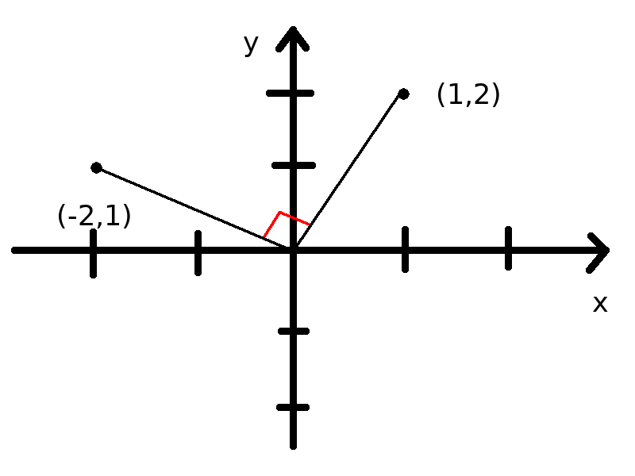

Rotation in 2d plane

## Classes

The code in the project will be split into classes for maintainability and readability. Most classes will just encapsulate the methods and the properties related to them, for example, there will be a game state class, which will contain function which operate on the state of the game. The game state class will have methods that arrange the balls into initial position and check the rules. There will also be separate classes for every game object in the game.

### Language Choice

At the beginning of the project, I was experienced in two programming languages - Python and Pascal. To pick one, I had to do some research on their suitability for the job.

The programming language of my choice should be able to deal with matrix manipulations outlined earlier. Both languages support array data structures, however, Python has a numerical computations library - Numpy[11]. This library has implemented functions for matrix operations, like matrix multiplication and more.

According to the Tiobe Index[12] and PYPL[13], Python is significantly more popular than Pascal and hence is a better language to use due to more resources available online (e.g. more StackOverlow questions/answers). This also suggests that python will have higher quality/variety of libraries due to a larger community. Additionally, Python is a duck-typed language, which means no explicit type declarations are required. This makes Python less verbose and more flexible, allowing for faster development, which is beneficial given a limited amount of time for development.

Finally, a game development library will be at the core of my project so it is important to pick a language with a mature, well maintained game development framework. A number of resources list the most popular libraries used for implementing games in Pascal[14][15]. All of these libraries are either missing completely (home page is broken), seriously outdated or are very immature. At the same time, Python has Pygame[16] which is open source, actively maintained (at the time of writing last commit 3 days ago) and mature (3k commits with 40 contributors).

## Objectives

- The rules of pool should be implemented in the game
- The game should run at more than 30 frames per second
- Physical interactions in the game should be realistic:
  - The movement of the balls should be affected by friction
  - The ball collisions should be inelastic
  - The game should detect and resolve ball-ball and ball-table side collisions
- Game animations look realistic:
  - The balls should visibly rotate when moving
  - The cue should move towards the ball when a player is hitting a ball
- A configuration file, which can change some of the in-game options like ball size or cue hit power
- An installation guide/README file for users

## Acceptable Limitations

After researching the multiplayer feature, I think it will be unfeasible for me to implement it alone. Implementing multiplayer will require good theoretical knowledge of networking and sockets, but the main problem is that adding multiplayer will add a lot of validation problems between clients, this would require a server, which I don’t have.

# Documented Design

## User Interface

A good pool game should implement the following features:

- The game screen should be big enough to see everything clearly.
- The balls should look realistic, and have easily distinguishable stripes on them so the players would not be confused which balls they need to pot.
- The game should have aiming lines to help the player aim. These lines are needed because in real life the player can line up the ball and see where it will go, so the game should have similar functionality.
- The game should have a minimal game menu with a button to start the game and leave the game.

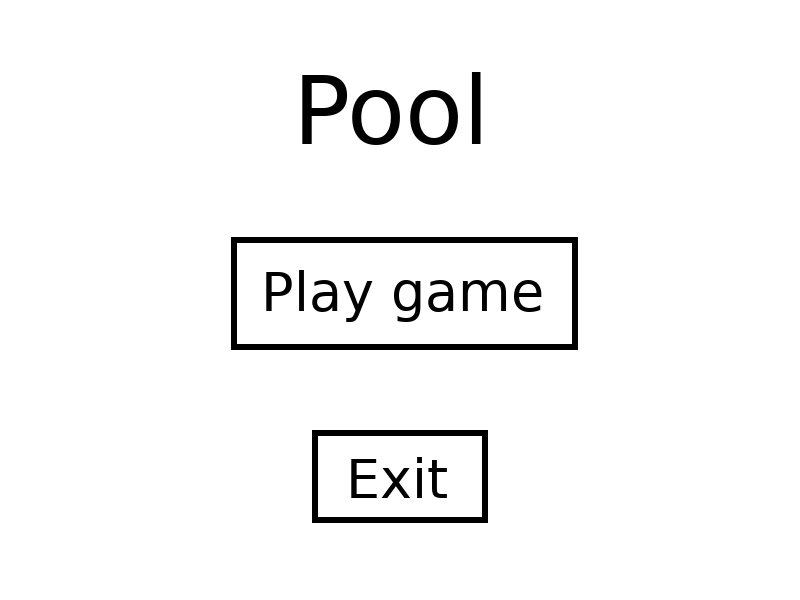

main menu model

In-game interface will consist of the cue, which can be aimed and retracted back to make a shot. The game will also have some indicators of the state of the game:

- A “current player” indicator (which can just be a label on the top)
- An indicator of which balls the players need to pot to win the game
- An indicator of whether the current player can move the cue ball

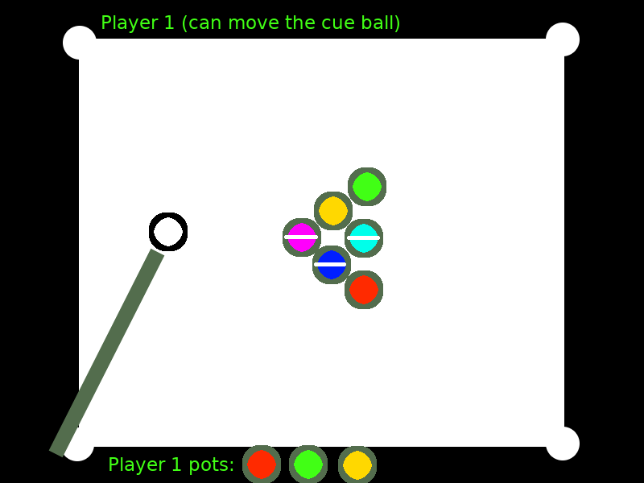

UI example figure

### Modular Design

- Main menu
  - The game
    - Stop the game
    - Game over
  - Quit the game

### Controls

- The user will use the mouse to move the cue or the cue ball (if it is movable).
- In the menu the main input method is the mouse, however the user should be able to quit the game by pressing ESC key.
- While in game, the user should be able to press the ESC button to leave to the main menu.

### Pool Rules

To implement the rules of pool I went online and read about the game rules[17], here are the main points:

- The first break should be performed behind the white line on the table, and the ball may be placed anywhere behind that line.
- If the players haven’t decided which group of balls they are on, and the player pots a ball or several balls of a particular group, that player now is on that group.
- To win the game, you must pot the 8 ball legally.
- You must first sink every ball from the group you are on, to pot the 8 ball.
- Failure to hit a ball from your group on your first ball hit, or not hitting a ball at all on your turn, gives your opponent a hit from his hand (which means that he is allowed to put the white ball anywhere on the table)
- If you pot the 8 ball illegally, you lose the game.

## Algorithms

### The main game loop

Pseudocode:

```
while True:
    while not game_is_over():
        resolve_collisions()
        move_everything()
        redraw_everything()

        if all_balls_stopped():
            apply_pool_rules()
            wait_for_cue_hit()
```

This is the whole game split into functions. Every turn, one player uses the cue, then while the balls are moving, the game will check for any collisions, resolve them and do one frame, meaning it will move every moving object and redraw everything. The main game loop will continue doing that until the game is over or the game is closed.

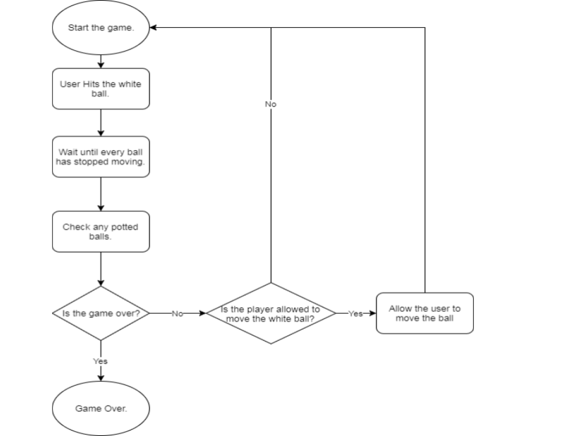

game flow

### Rendering

The ball can be split in 3 parts which must be rendered separately:

- The ball stripe
- The label (circle with the number)
- The solid color body

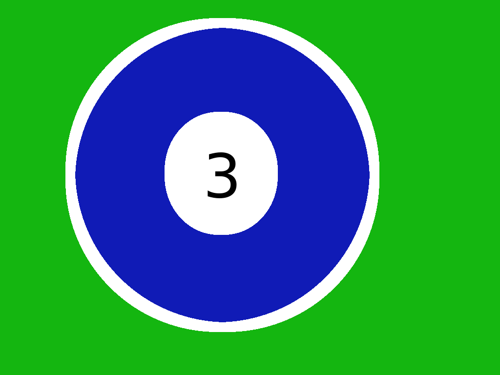

Initial position of the ball

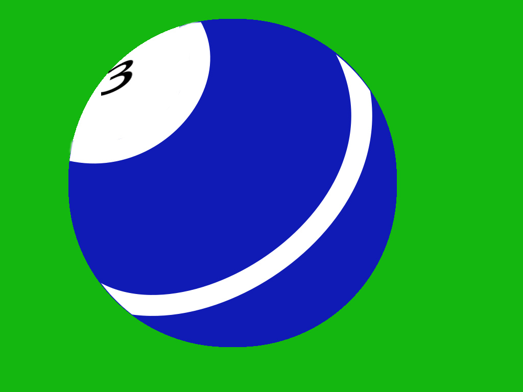

A possible position of the ball

A sphere of a solid color will look like a circle from any angle in 2-dimensions. That’s why we don’t need to worry about any rotations of the solid sphere component. Hence we can just draw the solid body as a solid circle and draw everything else on top.

The stripe on the ball will be modeled as an array of 3-dimensional vectors ($\vec k = (x,y,z)$). The line array $a$ is defined as

$$a=
\begin{bmatrix}
\vec k_{1}, & \vec k_{2}, & \vec k_{3}, & \dots, & \vec k_{n}
\end{bmatrix}$$

Where $\vec k_n$ is a 3d vector on the surface of the ball. We will draw lines from $\vec k_1$ to $\vec k_2$, from $\vec k_2$ to $\vec k_3$ and so on for every adjacent pair of points (a line from $\vec k_{i-1}$ to $\vec k_{i}$ for $i\in[2,n]$). This will draw a polygon that very closely follows the shape of the stripe.

When the ball moves the line array is rotated using rotation matrices. A 3d rotation matrix can be calculated from a rotation axis and an angle through which the ball needs to be rotated. We know the axis of rotation - it is the line perpendicular to the velocity vector and parallel to the table surface, and the angle of rotation is calculated using the formula
$$\theta=\frac{vt}{r}$$
where $v$ is the linear speed of the ball and $r$ is the radius of the ball with $\theta$ being in radians. The intuition for the formula is that when the ball is moving, every point on the circumference must touch the ground before it does a full rotation, therefore it must move $2\pi r$ units for a full rotation. The angle the ball has rotated is therefore given by $\theta = \frac{S}{r}$, where $S$ is the linear distance the ball has traveled. Then we substitute the formula $S=vt$ to get the aforementioned formula.

$$\begin{gather*}
a = cos(\frac{\phi}{2}) \\
b = v_{x}sin(\frac{\phi}{2}) \\
c = v_{y}sin(\frac{\phi}{2}) \\
d = v_{z}sin(\frac{\phi}{2})
\end{gather*}$$

With $\phi$ being the rotation angle and $\vec v=(v_{x},v_{y},v_{y})$ being the unit vector of the axis of the rotation[7][18][19].

The label will be tracked with a single point. That point will be on the top of the ball when it’s initialised and will be rotated with the same rotation matrix outlined earlier. Additionally, the label will be scaled depending on the orientation of the ball. For example, when the label is facing to the side, the width of the label sprite is squashed to values close to 0. To get the scale factor of this transformation, I will use the formula $SF=rd$, where $r$ is the radius of the ball, and $d$ is the distance of the label to the edge of the ball from the top-down view. One important thing to note is that this is a heuristic method. This technique produces realistic results, but isn’t how it exactly works in real life. One method which would produce better results is surfel modeling[1], but implementing something that complex is out of the scope of this project.

Pseudocode:

Initialisation:

```
line_point_array = []
delta_theta = 2*pi/point_num
#point_num is the number of points used for the line
for i in point_num:
   line_point_array.append([cos(i*delta_theta),sin(i*delta_theta),0])
label_point = [0,0,1]
```

Rotation matrix (taken from https://stackoverflow.com/a/6802723):

```
def rotation_matrix(axis, theta):
    axis = axis/pythagorean_distance(axis)
    a = cos(theta/2)
    b, c, d = -axis*sin(theta/2)
    aa, bb, cc, dd = a*a, b*b, c*c, d*d
    bc, ad, ac, ab, bd, cd = b*c, a*d, a*c, a*b, b*d, c*d
    return [[aa+bb-cc-dd, 2*(bc+ad), 2*(bd-ac)],
           [2*(bc-ad), aa+cc-bb-dd, 2*(cd+ab)],
           [2*(bd+ac), 2*(cd-ab), aa+dd-bb-cc]]
```

Applying the matrix:

```
rotation_angle = ball.speed  / ball_radius
perpendicular_velocity_vector = [-ball.velocity[1], ball.velocity[0], 0]
rotation_matrix = rotation_matrix(perpedicular_velocity_vector, rotation_angle)
for point in line_point_array:
    point = matrix_multiplication(point, rotation_matrix)
label_point = matrix_multiplication(label_point, rotation_matrix)
```

Drawing the stripe:

```
for i in point_num:
    if line_point_array[i][2]>=0 and line_point_array[i+1][2]>=0:
        draw_line(line_point_array[i], line_point_array[i+1])
```

### Object Movement

Most objects which appear in the game will have a velocity vector and a position vector. Every frame the computer will erase the old object and redraw it on its new position to simulate movement. For example, to simulate ball movement the computer will draw a circle of the background color on top of the old rendition of the ball (thus erasing it), add the velocity vector to the position vector of the ball and then draw a new rendering on its updated position.

If the objects don’t move too fast and the game is running at moderate frames-per-second, the movement will look smooth.

### Collision Detection

#### Ball-Ball

One way detect a ball-ball collision is to check the distances between ball centres every frame and, if that distance is less than the sum of their radii, that means that they have collided.

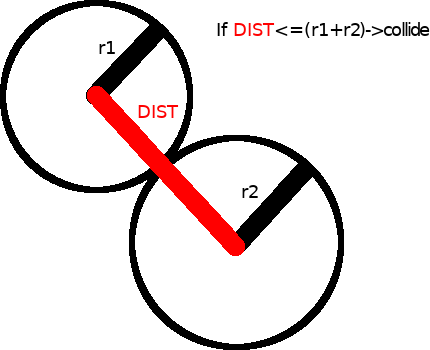

Pseudocode:

```
return (pythagorean_distance(ball1.pos-ball2.pos)<=2*ball_radius)
```

#### Ball-Pocket

In the game, any ball which has its centre of mass inside a pocket is considered potted and is instantly removed from the game. Therefore, the algorithm only needs to check if the distance from the centre of the ball to the centre of the pocket is smaller than the radius of the pocket, and if it is, the ball is removed. Because pockets are modeled as spheres, we use the same algorithm to detect collisions for both balls and pockets.

#### Ball-Line

This collision is called ball-line, because the table walls are modeled as lines. To detect such a collision we need to get the perpendicular distance from the centre of the ball to the line.

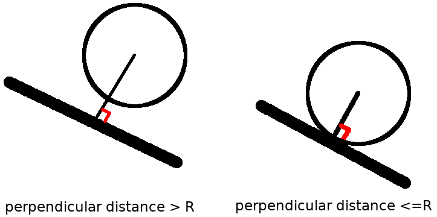

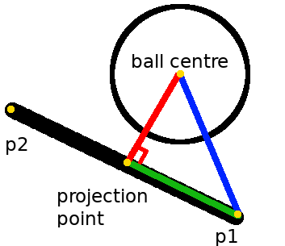

We know the position of the ball centre, its radius, and 2 points (p1 and p2 on the figure) which define the line. First we find the unit vector of the line (vector from p1 to p2) and the distance vector from one of the points to the ball centre (blue line on the figure). Then we get the distance from p1 to the perpendicular projection point using the *dot product* on the aforementioned vectors. Note that the result will be a scalar quantity. To get the actual projection point we multiply the scalar value by the unit line displacement vector we got earlier to get the projection point (as labeled on the figure). Then we can get the perpendicular distance from the line to the ball centre by using Pythagorean theorem. We can compare that distance to the balls radius to determine if the ball is colliding with the line.

However, there is one final caveat:

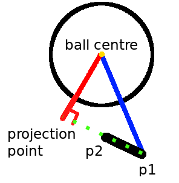

it’s possible for the projected point to be outside of the line. To check that its not the case, we check that the distance from p1 and p2 to the projected point is less than the length of the line (distance from p1 to p2).

Pseudocode:

```
#line[0] is the first point of the line and
#line[1] is the second point of the line
displacement_to_ball = ball.pos - line[0]
displacement_to_second_point = line[1] - line[0]
normalised_point_diff_vector = displacement_to_second_point /
        pythagorean_distance(displacement_to_second_point)
#distance from the first point to the perpendicular point on
#the line
projected_distance = dot_product(normalised_point_diff_vector,
                       displacement_to_ball)
closest_line_point = projected_distance * normalised_point_diff_vector
return (0 <= projected_distance <= pythagorean_distance(displacement_to_second_point)) and
    (pythagorean_distance(closest_line_point - ball.pos + line[0]) <= ball_randius)
```

### Collision resolution

#### Ball-Line

As mentioned in Analysis, when a ball collides with a line the perpendicular component of the balls velocity to the line is reversed and multiplied by $\frac{1+e}{2}$. The component parallel to the line is unchanged. This is because the force from the wall on the ball is applied strictly perpendicularly to the line.

Pseudocode:

```
#line[0] is the first point of the line and
#line[1] is the second point of the line
displacement_to_second_point = line[1] - line[0]
normalised_point_diff_vector = displacement_to_second_point /
                           pythagorean_distance(displacement_to_second_point)
perpendicular_vector = [-normalised_point_diff_vector[1], normalised_point_diff_vector[0]]
#the vector is multiplied by 2 to cancel out the initial velocity
#and then reverse it
ball.velocity = ball.velocity - 2 * dot_product(perpendicular_vector, ball.velocity) *
                perpendicular_vector * (1 + table_coeff_of_restitution) / 2
```

#### Ball-Ball

To resolve a ball-ball collision we need to split the velocities of both balls into 2 perpendicular components. One component is parallel to the vector connecting the centres of the balls and the other one perpendicular to the first component.

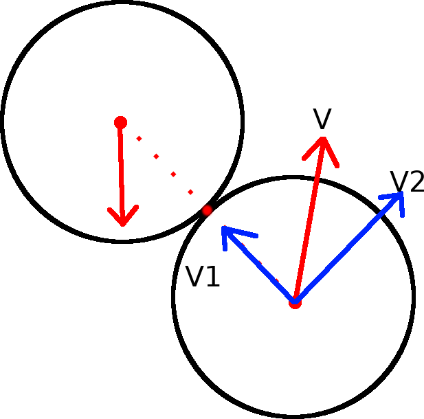

ball collision example

Just as with the ball-line collision scenario, the component perpendicular to the vector connecting the centres of the balls stays unchanged after the collision while the parallel component needs to be calculated using the inelastic collision formula[6]:

$$V'_1=\frac{(1+e)M_1}{M_1+M_2}V_2$$

Where $e$ is the coefficient of restitution (explained in analysis), $M_1$ and $M_2$ are the masses of the first and second balls, respectively. $V'_1$ is the velocity of the first ball after the collision and $V_2$ is the velocity of the second ball prior to the collision.

In our case, the masses of the balls are all the same, which gives us:
$$V'_1=\frac{(1+e)}{2}V_2$$
To summarise, we split the ball velocities into 2 vectors: one vector - $V_a$, which goes through the collision point and the other vector - $V_b$, which is at 90 degrees to the first vector , then the formula for the velocity after the collision is:
$$V'_1=\frac{(1+e)}{2}V_{a2}+V_{b1}$$
Pseudocode:

```
point_diff = ball2.pos - ball1.pos
distance = pythagorean_distance(ball1.position, ball2.position)
collision_vector = point_diff / distance
# rotate the vector 90 degrees clockwise to get the perpendicular vector
perpindicular_collision_vector = [collision_vector[1], -collision_vector[0]]
Va1 = dot_product(ball1.velocity, collision_vector)
Vb1 = dot_product(ball2.velocity, collision_vector)
Va2 = dot_product(ball1.velocity, perpindicular_collision_vector)
Vb2 = dot_product(ball2.velocity, perpinducular_collision_vector)
ball1.velocity = Vb1 * collision * (1 + ball_coeff_of_restitution)/2
                + Va2*perpendicular_collision_vector
ball2.velocity = Va1 * collision * (1 + ball_coeff_of_restitution)/2
                + Vb2*perpendicular_collision_vector
```

### Cue Click Detection

Because the cue is modeled as a rectangle, the problem here can be simplified down to figuring out if a 2d point is in a rectangle (which is defined with 4 2d points). To do that we find the area of 4 triangles which can be made with 4 rectangle points and the points. We can find the area of triangles using herons formula.

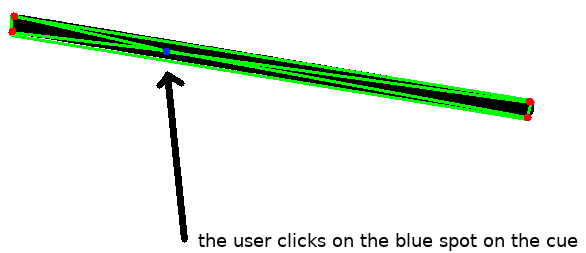

click inside cue

The area of the green triangles equals the area of the cue, therefore the click is inside the cue.

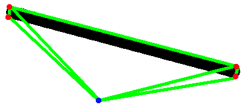

click outside cue

The user clicks on the blue dot which is outside the black cue. The sum of the areas of the green triangles is greater than the area of the cue, thus the point is outside of the cue.

Pseudocode:

```
#rectangle is an array of 2d points which define the cue
#rectangle[0] to rectangle[1] must be the tip of the cue
#for this to work
#point is a 2d point (the coordinates of users click)
inner_lines = [ pythagorean_distance(point, rectangle[0]),
                pythagorean_distance(point, rectangle[1]),
                pythagorean_distance(point, rectangle[2]),
                pythagorean_distance(point, rectangle[3])]
triangle_areas = [  herons(inner_lines[0],inner_lines[1],cue_width)
                    herons(inner_lines[1],inner_lines[2],cue_length),
                    herons(inner_lines[2],inner_lines[3],cue_width),
                    herons(inner_lines[3],inner_lines[0],cue_length)]
rect_area = cue_length * cue_width
return rect_area >= sum(triangle_areas)
```

## Installation

As seen in analysis, GitHub users had problems installing other games like this. I will add instructions for installing the game for Windows and Linux in the README file of the game.

I will also make a simple shell script for Linux which will create a virtual environment and install every dependency through PIP.

### Development considerations

#### Version Control

To be more productive and avoid code loss situations, I will use version control, specifically git, which is the most popular version control framework [20]. Storing a git repository exclusively on a local machine is dangerous since in case of a disk failure all data is lost. To ensure this never occurs, I will regularly upload my code to GitHub, which is a cloud service which allows storing git repositories on their server.

#### Additional Libraries and Library Management

For complex mathematical operations (mostly matrix operations in this project), I used Numpy, a numerical library for python which in addition to a wide range of scalar functions provides a multitude of vector functions.

For managing dependencies I chose pip (all project requirements are specified in requirements.txt), which is a common dependency manager used for python.

## Game Objects and Classes

Most game objects, like balls and cue, will be encapsulated into separate classes with for the ease of testing and maintaining. These classes will have methods and properties associated to them. For example, the ball class (figure 13) will be split in 4 different classes - the mathematical part of the ball, which will have things like the position and velocity vector as well as movement and force vectors. Then there will be 2 types of ball sprites - balls with solid color and balls with a stripe. I decided to go with the rule of thumb “composition over inheritance” and create instances of those classes in the main class instead of inheriting them. Double inheritance is possible in Python, however it introduces ambiguity and unneeded complexity.

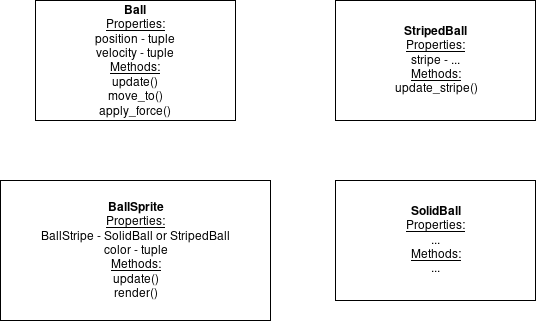

Ball object classes

## Input Validation

When a player is allowed change the game state, we must make sure that the player won’t abuse anything with these rules:

- When the player is allowed to move the ball, check that the player does not move the ball outside of the game border or into another ball.
- When the player is using the cue, it must not extend indefinitely (there should be a reasonable limit on the extension).
- The players should not be allowed to move the white ball out of the white line region on the first hit.

# Technical solution

## main.py

```
import pygame

import collisions
import event
import gamestate
import graphics
import config

was_closed = False
while not was_closed:
    game = gamestate.GameState()
    button_pressed = graphics.draw_main_menu(game)

    if button_pressed == config.play_game_button:
        game.start_pool()
        events = event.events()
        while not (events["closed"] or game.is_game_over or events["quit_to_main_menu"]):
            events = event.events()
            collisions.resolve_all_collisions(game.balls, game.holes,
                                              game.table_sides)
            game.redraw_all()

            if game.all_not_moving():
                game.check_pool_rules()
                game.cue.make_visible(game.current_player)
                while not ((events["closed"] or events["quit_to_main_menu"])
                           or game.is_game_over) and game.all_not_moving():
                    game.redraw_all()
                    events = event.events()
                    if game.cue.is_clicked(events):
                        game.cue.cue_is_active(game, events)
                    elif game.can_move_white_ball and game.white_ball.is_clicked(
                            events):
                        game.white_ball.is_active(game,
                                                  game.is_behind_line_break())
        was_closed = events["closed"]

    if button_pressed == config.exit_button:
        was_closed = True

pygame.quit()
```

## gamestate.py

```
import itertools
import math
import random
from enum import Enum

import numpy as np
import pygame
import zope.event

import ball
import config
import cue
import event
import graphics
import table_sprites
from ball import BallType
from collisions import check_if_ball_touches_balls


class Player(Enum):
    Player1 = 1
    Player2 = 2


class GameState:
    def __init__(self):
        pygame.init()
        pygame.display.set_caption(config.window_caption)
        event.set_allowed_events()
        zope.event.subscribers.append(self.game_event_handler)
        self.canvas = graphics.Canvas()
        self.fps_clock = pygame.time.Clock()

    def fps(self):
        return self.fps_clock.get_fps()

    def mark_one_frame(self):
        self.fps_clock.tick(config.fps_limit)

    def create_white_ball(self):
```

[output cut: 260 more lines]

```
    def first_hit_rule(self):
        # checks if the 1st white ball hit is the same as the players target ball type
        # for example if the current player hits a striped ball with the whit ball
        # but he should be potting solid balls, it is next players turn and he can move the white ball
        if not self.white_ball_1st_hit_is_set:
            self.turn_over(True)
        elif self.ball_assignment is not None:
            if not self.white_ball_1st_hit_8ball and self.ball_assignment[
                self.current_player] != self.white_ball_1st_hit_type:
                self.turn_over(True)
            # checks if the 8ball was the first ball hit, and
            # if so checks if the player needs to pot the 8ball
            # and if not he gets penalised
            elif self.white_ball_1st_hit_8ball:
                self.turn_over(not self.potting_8ball[self.current_player])
```

## physics.py

```
import math

import numpy as np

import config


def point_distance(p1, p2):
    dist_diff = p1 - p2
    return np.hypot(*dist_diff)


def distance_less_equal(p1, p2, dist):
    # does distance comparisons without calculating square roots
    dist_diff = p1 - p2
    return (dist_diff[0] ** 2 + dist_diff[1] ** 2) <= dist ** 2


def ball_collision_check(ball1, ball2):
    # distance check followed by checking if either of the balls are moving
    # followed by vector projection check, to see if both are moving towards
    # each other
    return distance_less_equal(ball1.pos, ball2.pos, 2 * config.ball_radius) and \
           np.count_nonzero(
               np.concatenate((ball1.velocity, ball2.velocity))) > 0 and \
           np.dot(ball2.pos - ball1.pos, ball1.velocity - ball2.velocity) > 0


def collide_balls(ball1, ball2):
    point_diff = ball2.pos - ball1.pos
    dist = point_distance(ball1.pos, ball2.pos)
    # normalising circle distance difference vector
    collision = point_diff / dist
    # projecting balls velocity ONTO difference vector
    ball1_dot = np.dot(ball1.velocity, collision)
    ball2_dot = np.dot(ball2.velocity, collision)
    # since the masses of the balls are the same, the velocity will just switch
    ball1.velocity += (ball2_dot - ball1_dot) * collision * 0.5 * (
                1 + config.ball_coeff_of_restitution)
    ball2.velocity += (ball1_dot - ball2_dot) * collision * 0.5 * (
```

[output cut: 50 more lines]

```
        return -config.ball_radius / 3 <= projected_distance <= \
           np.hypot(*(displacement_to_second_point)) + config.ball_radius / 3
           and np.hypot(*(closest_line_point - ball.pos + line.line[0])) <= \
           config.ball_radius and np.dot(perpendicular_vector, ball.velocity) <= 0


def collide_line_ball(line, ball):
    displacement_to_second_point = line.line[1] - line.line[0]
    normalised_point_diff_vector = displacement_to_second_point / \
                                   np.hypot(*(displacement_to_second_point))
    perpendicular_vector = np.array(
        [-normalised_point_diff_vector[1], normalised_point_diff_vector[0]])
    ball.velocity -= 2 * np.dot(perpendicular_vector, ball.velocity) * \
                     perpendicular_vector * 0.5 * (
                                 1 + config.table_coeff_of_restitution)
```

## collisions.py

```
import itertools
import random

import zope.event

import config
import event
import physics


def resolve_all_collisions(balls, holes, table_sides):
    # destroys any circles that are in a hole
    for ball_hole_combination in itertools.product(balls, holes):
        if physics.distance_less_equal(ball_hole_combination[0].ball.pos,
                                       ball_hole_combination[1].pos,
                                       config.hole_radius):
            zope.event.notify(
                event.GameEvent("POTTED", ball_hole_combination[0]))

    # collides balls with the table where it is needed
    for line_ball_combination in itertools.product(table_sides, balls):
        if physics.line_ball_collision_check(line_ball_combination[0],
                                             line_ball_combination[1].ball):
            physics.collide_line_ball(line_ball_combination[0],
                                      line_ball_combination[1].ball)

    ball_list = balls.sprites()
    # ball list is shuffled to randomize ball collisions on the 1st break
    random.shuffle(ball_list)

    for ball_combination in itertools.combinations(ball_list, 2):
        if physics.ball_collision_check(ball_combination[0].ball,
                                        ball_combination[1].ball):
            physics.collide_balls(ball_combination[0].ball,
                                  ball_combination[1].ball)
            zope.event.notify(event.GameEvent("COLLISION", ball_combination))


def check_if_ball_touches_balls(target_ball_pos, target_ball_number, balls):
    touches_other_balls = False
    for ball in balls:
        if target_ball_number != ball.number and \
                physics.distance_less_equal(ball.ball.pos, target_ball_pos,
                                            config.ball_radius * 2):
            touches_other_balls = True
            break
    return touches_other_balls
```

## ball.py

```
import itertools
import math
from enum import Enum

import numpy as np
import pygame

import collisions
import config
import event
import physics


class Ball():
    def __init__(self):
        self.pos = np.zeros(2, dtype=float)
        self.velocity = np.zeros(2, dtype=float)

    def apply_force(self, force, time=1):
        # f = ma, v = u + at -> v = u + (f/m)*t
        self.velocity += (force / config.ball_mass) * time

    def set_velocity(self, new_velocity):
        self.velocity = np.array(new_velocity, dtype=float)

    def move_to(self, pos):
        self.pos = np.array(pos, dtype=float)

    def update(self, *args):
        self.velocity *= config.friction_coeff
        self.pos += self.velocity

        if np.hypot(*self.velocity) < config.friction_threshold:
            self.velocity = np.zeros(2)


class BallType(Enum):
    Striped = "striped"
    Solid = "solid"

```

[output cut: 144 more lines]

```
                    config.table_margin + config.ball_radius + config.hole_radius,
                    events["mouse_pos"])) and \
                    np.all(np.greater(
                        config.resolution - config.table_margin - config.ball_radius - config.hole_radius,
                        events["mouse_pos"])) and \
                    not collisions.check_if_ball_touches_balls(
                        events["mouse_pos"], self.number, game_state.balls):
                if behind_separation_line:
                    if events["mouse_pos"][0] <= config.white_ball_initial_pos[
                        0]:
                        self.move_to(events["mouse_pos"])
                else:
                    self.move_to(events["mouse_pos"])
            game_state.redraw_all()
        game_state.cue.make_visible(game_state.current_player)
```

## cue.py

```
import math

import numpy as np
import pygame

import config
import event
import gamestate
import physics


class Cue(pygame.sprite.Sprite):
    def __init__(self, target):
        pygame.sprite.Sprite.__init__(self)
        self.angle = 0
        self.color = config.player1_cue_color
        self.target_ball = target
        self.visible = False
        self.displacement = config.ball_radius
        self.sprite_size = np.repeat(
            [config.cue_length + config.cue_max_displacement], 2)
        self.clear_canvas()

    def clear_canvas(self):
        # create empty surface as a placeholder for the cue
        self.image = pygame.Surface(2 * self.sprite_size)
        self.image.fill((200, 200, 200))
        self.image.set_colorkey((200, 200, 200))
        self.rect = self.image.get_rect()
        self.rect.center = self.target_ball.ball.pos.tolist()

    def update(self, *args):
        if self.visible:
            self.image = pygame.Surface(2 * self.sprite_size)
            # color which will be ignored
            self.image.fill((200, 200, 200))
            self.image.set_colorkey((200, 200, 200))

            sin_cos = np.array([math.sin(self.angle), math.cos(self.angle)])
            initial_coords = np.array([math.sin(self.angle + 0.5 * math.pi),
```

[output cut: 98 more lines]

```
        prev_angle = self.angle
        # hack to avoid div by zero
        if not displacement_from_ball_to_mouse[0] == 0:
            self.angle = 0.5 * math.pi - math.atan(
                displacement_from_ball_to_mouse[1] /
                displacement_from_ball_to_mouse[0])
            if displacement_from_ball_to_mouse[0] > 0:
                self.angle -= math.pi

        game_state.redraw_all(update=False)
        self.draw_lines(game_state, self.target_ball, prev_angle +
                        math.pi, config.table_color)
        self.draw_lines(game_state, self.target_ball, self.angle +
                        math.pi, (255, 255, 255))
        pygame.display.flip()
```

## graphics.py

```
import numpy as np
import pygame

import config
import event


class Canvas:
    def __init__(self):
        if config.fullscreen:
            config.set_max_resolution()
            self.surface = pygame.display.set_mode(config.resolution,
                                                   pygame.FULLSCREEN)
        else:
            self.surface = pygame.display.set_mode(config.resolution)
        self.background = pygame.Surface(self.surface.get_size())
        self.background = self.background.convert()
        self.background.fill(config.table_color)
        self.surface.blit(self.background, (0, 0))


def add_separation_line(canvas):
    # white ball separation line
    pygame.draw.line(canvas.background, config.separation_line_color,
                     (config.white_ball_initial_pos[0], 0),
                     (config.white_ball_initial_pos[0], config.resolution[1]))


def create_buttons(text, text_font, text_color_normal, text_color_on_hover):
    # this function generates button objects using button text, button font,
    # normal colour and color of the text when
    # the mouse is hovering over the button

    button_size = np.array(
        [text_font[num].size(text[num]) for num in range(len(text))])
    # generating button objects
    buttons = [
        # text when mouse is outside the button range
        [text_font[num].render(text[num], False, text_color_normal[num]),
         # text when mouse is inside the button range
```

[output cut: 56 more lines]

```


def draw_rects(button_size, buttons, game_state, text_starting_place,
               emit=list()):
    # drawing a rectangle around the button text
    for num in range(len(buttons)):
        game_state.canvas.surface.blit(
            buttons[num][0], text_starting_place[num])
        # emit contains indexes of buttons which do not need a rectangle around them
        if not num in emit:
            pygame.draw.rect(game_state.canvas.surface, config.menu_text_color,
                             np.concatenate((text_starting_place[num] -
                                             config.menu_spacing,
                                             button_size[num] +
                                             config.menu_spacing * 2)), 1)
```

## table_sprites.py

```
import numpy as np
import pygame

import config
import gamestate


class Hole(pygame.sprite.Sprite):
    def __init__(self, x, y):
        pygame.sprite.Sprite.__init__(self)
        self.image = pygame.Surface(
            (2 * config.hole_radius, 2 * config.hole_radius))
        # color which will be ignored
        self.image.fill((200, 200, 200))
        self.image.set_colorkey((200, 200, 200))

        pygame.draw.circle(self.image, (0, 0, 0),
                           (config.hole_radius, config.hole_radius),
                           config.hole_radius, 0)
        self.rect = self.image.get_rect()
        self.rect.center = (x, y)
        self.pos = np.array([x, y])


# this class holds properties of a table side line, but doesn't actually
# draw it
class TableSide():
    def __init__(self, line):
        self.line = np.array(line)
        self.middle = (self.line[0] + self.line[1]) / 2
        self.size = np.round(np.abs(self.line[0] - self.line[1]))
        self.length = np.hypot(*self.size)
        if np.count_nonzero(self.size) != 2:
            # line is perpendicular to y or x axis
            if self.size[0] == 0:
                self.size[0] += 1
            else:
                self.size[1] += 1


```

[output cut: 74 more lines]

```
        # generates the top left label (which players turn is it and if he can move the ball)
        top_left_text = ""
        if game_state.can_move_white_ball:
            top_left_text += config.penalty_indication_text
        if game_state.current_player.value == 1:
            top_left_rendered_text = self.font.render(
                config.player1_turn_label + top_left_text,
                False, config.player1_cue_color)
        else:
            top_left_rendered_text = self.font.render(
                config.player2_turn_label + top_left_text,
                False, config.player2_cue_color)
        text_pos = [config.table_margin + config.hole_radius * 3,
                    config.table_margin - self.font.size(top_left_text)[1] / 2]
        self.image.blit(top_left_rendered_text, text_pos)
```

## event.py

```
import numpy as np
import pygame


class GameEvent():
    def __init__(self, event_type, data):
        self.type = event_type
        self.data = data


def set_allowed_events():
    # only allow keypress events to avoid waisting cpu type on checking useless events
    pygame.event.set_allowed([pygame.KEYDOWN, pygame.QUIT])


def events():
    closed = False
    quit = False

    for event in pygame.event.get():
        if event.type == pygame.QUIT:
            closed = True
        if event.type == pygame.KEYDOWN:
            if event.key == pygame.K_ESCAPE:
                quit = True

    return {"quit_to_main_menu": quit,
            "closed": closed,
            "clicked": pygame.mouse.get_pressed()[0],
            "mouse_pos": np.array(pygame.mouse.get_pos())}
```

## config.py

```
import math

import numpy as np
import pygame


# fonts need to be initialised before using
def get_default_font(size):
    font_defualt = pygame.font.get_default_font()
    return pygame.font.Font(font_defualt, size)


def set_max_resolution():
    infoObject = pygame.display.Info()
    global resolution
    global white_ball_initial_pos
    resolution = np.array([infoObject.current_w, infoObject.current_h])
    white_ball_initial_pos = (resolution + [table_margin + hole_radius, 0]) * [
        0.25, 0.5]


# window settings
fullscreen = False
# fullscreen resolution can only be known after initialising the screen
if not fullscreen:
    resolution = np.array([1000, 500])
window_caption = "Pool"
fps_limit = 60

# table settings
table_margin = 40
table_side_color = (200, 200, 0)
table_color = (0, 100, 0)
separation_line_color = (200, 200, 200)
hole_radius = 22
middle_hole_offset = np.array(
    [[-hole_radius * 2, hole_radius], [-hole_radius, 0],
     [hole_radius, 0], [hole_radius * 2, hole_radius]])
side_hole_offset = np.array([
    [- 2 * math.cos(math.radians(45)) * hole_radius - hole_radius, hole_radius],
```

[output cut: 70 more lines]

```
menu_margin = 20
menu_spacing = 10
menu_title_font_size = 40
menu_option_font_size = 20
exit_button = 2
play_game_button = 1

# in-game ball target variables
player1_target_text = 'P1 balls - '
player2_target_text = 'P2 balls - '
target_ball_spacing = 3
player1_turn_label = "Player 1 turn"
player2_turn_label = "Player 2 turn"
penalty_indication_text = " (click on the ball to move it)"
game_over_label_font_size = 40
```

# Testing

## Bugs Fixed During the Development of the Program

### “Reverse” Shot Bug

If the cue is brought very close to the white ball, the game sometimes applied the force in the other direction on the ball, meaning the ball would move towards the ball after the hit.

```
new_velocity = -(self.displacement - config.ball_radius - config.cue_safe_displacement) * \
        config.cue_hit_power * np.array([math.sin(self.angle), math.cos(self.angle)])
```

The game calculated the new velocity of the ball using this formula. `self.displacement` is the displacement of the cue from the centre of the ball, `config.cue_safe_displacement` is the distance from the ball the cue could be displaced and released without affecting the ball. Here is the if statement which check if a ball hit went through.

```
if self.displacement > config.ball_radius:
    self.ball_hit()
```

The if statement was missing the `config.cue_safe_displacement`, therefore if the cue was brought really close to the ball and if the value of `config.cue_safe_displacement` was bigger that zero, `self.displacement - config.ball_radius - config.cue_safe_displacement` could be less than zero and so reverse the direction of the hit.

Code changed (pool/cue.py line 114)[2]:

```
-        if self.displacement > config.ball_radius:
+        if self.displacement > config.ball_radius+config.cue_safe_displacement:
            self.ball_hit()
```

This change will insure that `self.displacement - config.ball_radius - config.cue_safe_displacement` will be bigger than zero, thus fixing the bug.

### Collision Resolution Bug

Sometimes, during the play of the game, the balls would “stick” to each other. Turns out there was a problem with the resolution of the collision, or more precisely, when it was triggered.

Collisions are checked for every frame. Figure 18 shows a possible position of the balls 1 frame before the collision and figure 19 shows the same balls in the next frame. The problem is caused by the ball overlap. When the balls collide, there will be some overlap and if the balls are moving quickly, the overlap might be significant.

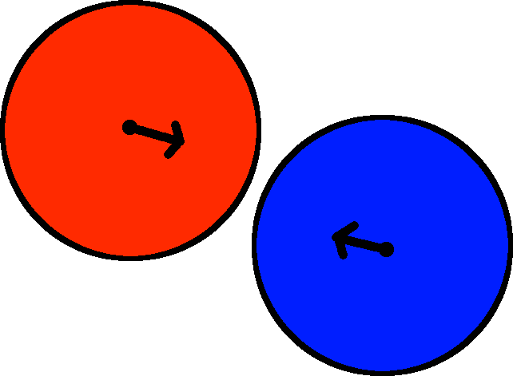

one frame before the collision

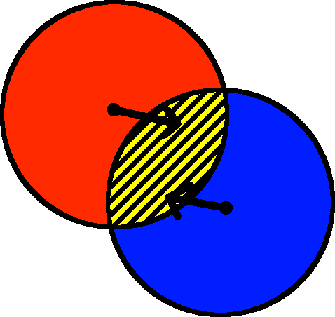

collision

Because the collision is inelastic the balls will lose some kinetic energy, therefore they will be moving slower after collision (as shown on figure 20).

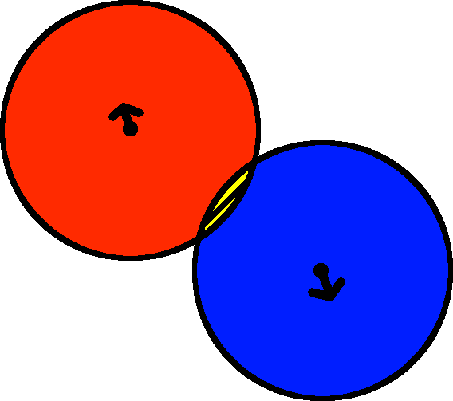

one frame after the collision

After colliding and moving once (one frame) they balls can still be inside each other, and thus the collision detection algorithm will trigger in the next frame again. If collision resolution algorithm is called on balls which are moving in opposite directions, the vectors will be reversed, and on the next frame the balls will be moving towards each other, making the process repeat indefinitely, which in turn makes the balls stick.

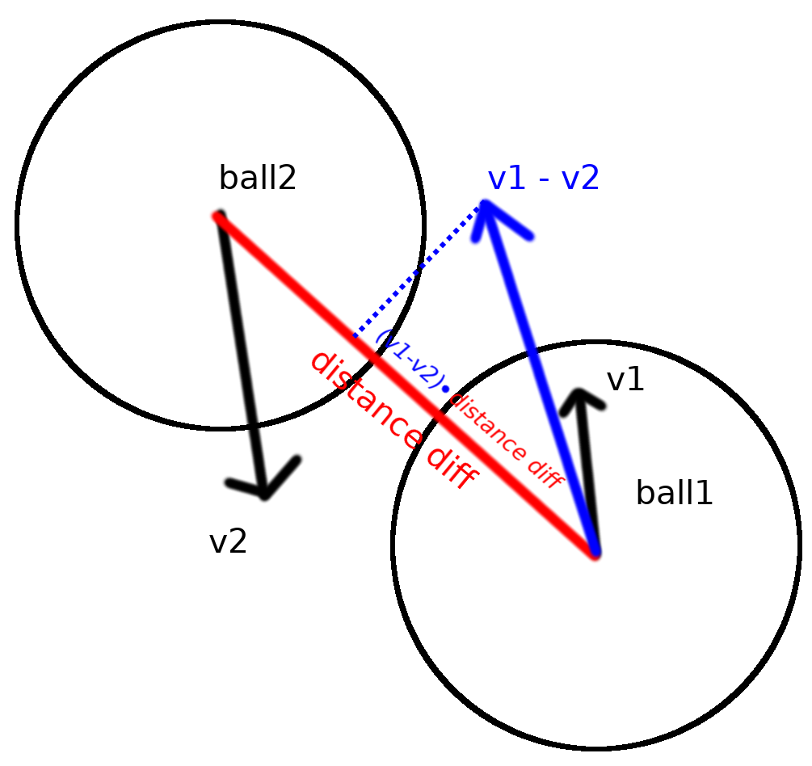

vectors with dot product

To resolve the collision properly we will take the dot product of the difference between the centres of 2 balls (labeled *distance diff* on figure 21) and the velocity difference vector (labeled as *v1-v2*). If the result is positive that means that the balls are moving towards each other and we can collide them, otherwise we ignore them.

**Code changed**:

Added the dot product check in function *collide_balls*[3]:

```
+def collide_balls(ball1, ball2):
+    point_diff = ball2.pos-ball1.pos
+    system_velocity = ball1.velocity-ball2.velocity
...
+    if np.dot(point_diff,system_velocity)>0:
..
```

Later reworked into:

```
def ball_collision_check(ball1, ball2):
    # distance check followed by checking if either of the balls are moving
    # followed by vector projection check, to see if both are moving towards
    # each other
    return distance_less_equal(ball1.pos, ball2.pos, 2 * config.ball_radius) and \
        np.count_nonzero(np.concatenate((ball1.velocity, ball2.velocity))) > 0 and \
        np.dot(ball2.pos - ball1.pos, ball1.velocity - ball2.velocity) > 0
```

## White Box Testing (Unit Testing)

In my game there are two main things to test - the process of the physical simulation, meaning the mathematics behind the collisions, collision detection and others, and the user interface. To test the mathematics, I’ve made a set of tests in a form of a script, which, when executed, runs the main program with the test input data. These tests are considered white box testing, more specifically, unit testing, because I am testing specific functions of the program. To make the job of testing the game with every change easier, I have made unit tests which are executed on my code every time I make a commit to GitHub. The unit tests are included with the game in the folder “tests”, the tests contain some input, which is used with the functions of the game which are responsible for a specific task. Lets look at a particular example:

```
def test_point_distance1(self):
    assert physics.point_distance(np.array([0, 0]), np.array([3, 4])) == 5
```

This function tests the function responsible for calculating the distance between two points. The function uses the function to calculate the distance between points (0,0) and (3,4), and compares it to 5. If the function does not return 5, the test returns an exception. Here is another, more complicated example of an edge case test:

```
def test_movement4(self):
    ball1.set_velocity((1, 1))
    ball2.move_to(-fortyfive_degree_position)
    ball2.set_velocity((1, 1))
    assert not physics.ball_collision_check(ball1, ball2)
```

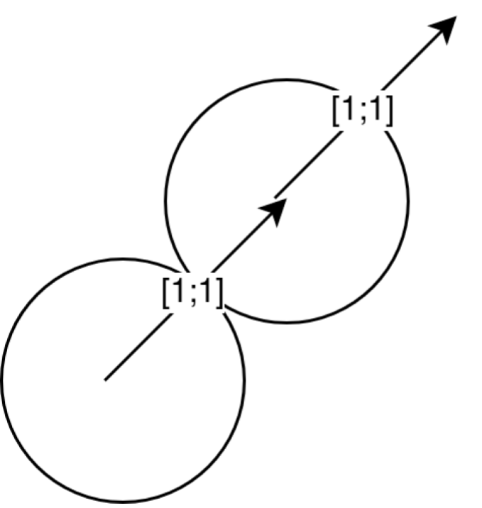

test 1

The test sets the balls such that they are touching, however, both balls are moving with the same velocity. That means there is no collision.

This is an example of an extreme test:

```
def test_movement10(self):
    ball1.set_velocity((0, 1))
    ball2.move_to((0, ball_radius * 2))
    ball2.set_velocity((200000000, -200000000000))
    assert physics.ball_collision_check(ball1, ball2)
```

The values in the test are exaggerated so that we know that the game can handle extreme values.

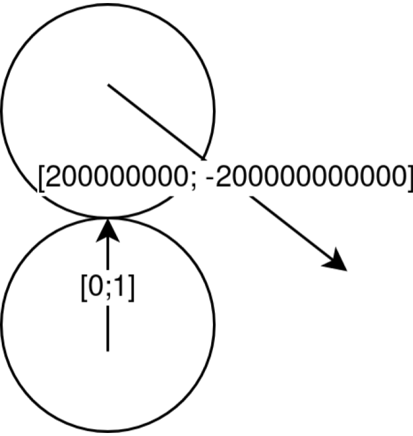

test2

For executing tests I used PyTest, a popular python unit-testing library. I also set up a simple continuous integration pipeline which runs all of my tests on a git-push to GitHub. For this I used the Travis CI service.

### How To Run the Tests

The file contains many tests, including matrix transformation tests, line to ball collision tests and the triangle area test. Here is the file itself:

```
import itertools
import math

import numpy as np

from pool import ball
from pool import physics
from pool import table_sprites
from pool.config import ball_radius


class TestPointDistance():
    def test_point_distance1(self):
        assert physics.point_distance(np.array([0, 0]), np.array([3, 4])) == 5

    def test_point_distance2(self):
        assert physics.point_distance(
            np.array([0, -10]), np.array([0, -10])) == 0

    def test_point_distance3(self):
        assert physics.point_distance(
            np.array([10, 0]), np.array([-10, 0])) == 20


class TestTriangleArea():
    def test_triangle_area1(self):
        assert physics.triangle_area(1, 1, 0) == 0

    def test_triangle_area2(self):
        assert physics.triangle_area(3, 4, 5) == 0.5 * 3 * 4


class TestRotationMatrix():
    def test_rotation_matrix1(self):
        for x, y, z in itertools.product(np.linspace(-1, 1, 5), repeat=3):
            if x != 0 or y != 0 or z != 0:
                assert np.all(physics.rotation_matrix(
                    np.array([x, y, z]), 0) == np.identity(3))

    def test_rotation_matrix2(self):
```

[output cut: 166 more lines]

```

    def test_line_ball_collision5(self):
        ball1.move_to([5, ball_radius])
        ball1.set_velocity([1, -1])
        assert physics.line_ball_collision_check(table_side_2, ball1)
        physics.collide_line_ball(table_side_2, ball1)
        assert np.all(np.around(ball1.velocity, 0) == [1., 1.])

    def test_line_ball_collision6(self):
        ball1.move_to(table_side_1.middle +
                      np.array([1., -1.]) * (ball_radius ** 0.5))
        ball1.set_velocity([1, -1])
        assert physics.line_ball_collision_check(table_side_1, ball1)
        physics.collide_line_ball(table_side_1, ball1)
        assert np.all(np.around(ball1.velocity, 0) == [-1., 1.])
```

Here is me running the tests on my machine on the latest pool build.

```
PYTHONPATH=./pool py.test --cov=.
========================= test session starts ==========================
platform linux -- Python 3.6.4, pytest-3.2.3, py-1.5.2, pluggy-0.4.0
rootdir: /home/max/code/python/pool, inifile:
plugins: cov-2.5.1, asyncio-0.8.0
collected 31 items

tests/test_physics.py ...............................

----------- coverage: platform linux, python 3.6.4-final-0 -----------
Name                    Stmts   Miss  Cover
-------------------------------------------
pool/__init__.py            0      0   100%
pool/ball.py              120     84    30%
pool/collisions.py         26     18    31%
pool/config.py             61      5    92%
pool/cue.py               100     80    20%
pool/event.py              18     12    33%
pool/gamestate.py         210    170    19%
pool/graphics.py           49     38    22%
pool/main.py               31     31     0%
pool/physics.py            44      7    84%
pool/table_sprites.py      77     56    27%
-------------------------------------------
TOTAL                     736    501    32%


====================== 31 passed in 0.39 seconds =======================
```

Tests for other builds and instructions on how to run the tests yourself can be found on the GitHub repository page[^1]. The records of how the build passes the tests are available on GitHub[^2] or on Travis-ci[^3].

# Evaluation

# References

[1] Jeroen van Baar Hanspeter Pfister Matthias Zwicker. Surfels: Surface elements as rendering primitives. Retrieved from https://graphics.ethz.ch/research/past_projects/surfels/surfels/index.html

[2] Maksims Kovalovs. Commit 872bdde305882ee68b771a3a03be3ab264d586ca - fixed a "reverse shot" bug. Removed graphics optimisation. Retrieved from https://github.com/max-kov/pool/commit/872bdde305882ee68b771a3a03be3ab264d586ca#diff-907fb60709078447681c52022334d974R113

[3] Maksims Kovalovs. Commit 5b35af32b22ac06268ee5231a2aa6834f599d59c - migrated to numpy. Retrieved from https://github.com/max-kov/pool/commit/5b35af32b22ac06268ee5231a2aa6834f599d59c#diff-1919d6b68248eec2b8d15bbc72b8e357R31

[4] raysmith619. Two dimensional pool game in python. Retrieved from https://github.com/raysmith619/PoolGame

[5] thinkpixellab. An html5 pool game...with bombs! Retrieved from https://github.com/CIS580F17/pool

[6] vlab.amrita.edu. Elastic and inelastic collision. Retrieved from http://vlab.amrita.edu/?sub=1&brch=68&sim=189&cnt=1

[7] WolframMathWorld. Rotation matrix. Retrieved from http://mathworld.wolfram.com/RotationMatrix.html

[8] User installation issue. Retrieved from https://github.com/thinkpixellab/agent8ball/issues/31

[9] Agent8ball commit history. Retrieved from https://github.com/thinkpixellab/agent8ball/commits/master

[10] Tyre modelling for rolling resistance. Retrieved from publications.lib.chalmers.se/records/fulltext/200040/200040.pdf

[11] Numpy library main website. Retrieved from http://www.numpy.org/

[12] TIOBE index website. Retrieved from https://www.tiobe.com/tiobe-index/

[13] PYPL popularity of programming language. Retrieved from http://pypl.github.io/PYPL.html

[14] Game engine. Retrieved from http://wiki.freepascal.org/Game_Engine

[15] The podcast about the delphi programming language, tools, news and community. Retrieved from http://delphi.org/2011/10/pascal-game-development

[16] Pygame github page. Retrieved from https://github.com/pygame/pygame

[17] Pool rules. Retrieved from http://www.epa.org.uk/wrules.php

[18] Retrieved from graphics.stanford.edu/courses/cs348a-17-winter/ReaderNotes/handout12.pdf

[19] Retrieved from graphics.stanford.edu/courses/cs348a-17-winter/ReaderNotes/handout17.pdf

[20] Version control systems popularity in 2016. Retrieved from https://rhodecode.com/insights/version-control-systems-2016

[^1]: https://github.com/max-kov/pool
[^2]: https://github.com/max-kov/pool/commits/master
[^3]: https://travis-ci.org/max-kov/pool/builds